# S6: tabelle e figure secondo Morris

Roadmap Morris 2019, ramo morris-v4

Data di Pubblicazione

18 ottobre 2026

## In breve: tabelle e figure mostrano l’incertezza, e cosa cambia nello scenario costruito sui dati reali?

**A cosa serviva.** Le linee guida di Morris chiedono che ogni numero di tabelle e figure porti con sé il suo errore Monte Carlo, che sia arrotondato di conseguenza e che ci sia almeno un grafico delle stime replicato per replicato. Abbiamo rifatto così tutte le tabelle e le figure del paper. Poi abbiamo ricontrollato le frasi di confronto nello scenario costruito sui dati reali (la coorte neonatale di ecografia polmonare), che hai deciso di portare nel testo principale. Lungo la strada abbiamo trovato e corretto un guasto del modello marginalizzato multilivello con le serie lunghe.

**Cosa abbiamo trovato.**

1. **Il modello marginalizzato multilivello sbagliava con le serie lunghe per un problema di stima che abbiamo trovato e corretto; con la correzione è il metodo meglio tarato in media.**
   - Dove la variabilità tra soggetti può cambiare nel tempo, il modello stima quanto cambia, ma solo come cambiamento positivo. Nei nostri dati il cambiamento vero è quasi zero, cioè sul limite consentito. In molti dataset l’algoritmo salta verso quel limite: la stima del trattamento si sposta, oppure l’errore standard crolla. Lo spostamento non si riduce con più soggetti o più visite, mentre l’errore standard sì: per questo i falsi positivi crescevano con soggetti e visite.
   - Abbiamo rianalizzato tutti i 1,69 milioni di dataset già simulati di quegli scenari con un controllo fissato prima: se l’algoritmo non converge o la stima è sul limite, si usa il modello senza quel termine. Il fit dello studio si riproduce esattamente in ogni dataset.
   - Con il controllo, negli scenari senza effetto del trattamento nessuna delle 864 situazioni simulate supera chiaramente 7,5 falsi positivi su 100 (prima erano 138). Con 8-10 visite lo scarto medio dal 5% scende da 1,8-2,8 punti a 0,7 (Fay e Graubard: 1,1). La capacità di trovare un effetto vero resta praticamente la stessa.
2. **Con il modello marginalizzato corretto cambiano 30 delle 156 frasi di confronto del paper.**
   - Non regge più che la correzione di Fay e Graubard sia la più vicina al 5% in media, né che abbia meno situazioni fuori taratura: ora fa meglio il modello marginalizzato. Non regge più che il modello marginalizzato dia più falsi positivi di Fay e Graubard sugli stessi dati.
   - Resta, e si rafforza, che il modello marginalizzato sbaglia di meno nella situazione peggiore. Con la distribuzione t, Fay e Graubard resta migliore nella situazione peggiore sui dati generati sulla scala della popolazione.
3. **Tabelle e figure sono pronte, con l’incertezza accanto a ogni numero.**
   - Dieci tabelle per le simulazioni principali e dieci per lo scenario sui dati reali, con il modello marginalizzato corretto; la versione precedente resta come analisi di sensibilità. Tutti i 912 numeri delle tabelle e i 12.261 valori delle figure sono stati riletti dal file da cui vengono.
   - La Figura 1 ha gli intervalli Monte Carlo e nessun titolo sopra i pannelli; la Figura 2 mostra i falsi positivi in ciascuna delle 1.512 situazioni simulate; nel materiale supplementare va il grafico degli intervalli di confidenza replicato per replicato.
4. **Nello scenario sui dati reali cambiano due confronti; lì la correzione non tocca nulla, perché quel modello non ha il termine che dava problemi.**
   - Il modello marginalizzato non è più il metodo che sbaglia di meno nella situazione peggiore e dà circa 2 falsi positivi su 100 più di Fay e Graubard.
   - Il vantaggio di potenza del test di Wald sul modello misto (il modello logistico a effetti casuali per soggetto) si rovescia: Fay e Graubard trova un effetto vero 4-5 volte su 100 più spesso con l’algoritmo predefinito di lme4, 1,4-2,5 con bobyqa. Il motivo sono fit del modello misto che non convergono e hanno un errore standard quasi nullo.
5. **Guardando le situazioni simulate una per una, due strategie restano sempre tarate.**
   - La correzione di Fay e Graubard con la distribuzione t e il modello marginalizzato corretto con la distribuzione t non superano mai chiaramente 7,5 falsi positivi su 100, in nessuna delle 1.512 situazioni. “Chiaramente” vuol dire anche tenendo conto dell’errore della simulazione in quella situazione.
   - Fay e Graubard risponde un po’ più spesso (92 dataset su 100 contro 91). Il modello marginalizzato è molto meno spesso troppo prudente con 2-3 visite: con 35-55 soggetti succede in 3 situazioni su 102, contro 28.
   - Il test del rapporto di verosimiglianza sul modello misto risponde quasi sempre, ma supera chiaramente la soglia in 216 situazioni; la regola del paper, che premia chi risponde, lo raccomanderebbe fino a 25 soggetti.

**Cosa devi decidere.**

1. **Quale regola mettiamo nella Figura 1? Consiglio: prima la taratura, poi la disponibilità, come avevo proposto. Ne esce ancora la correzione di Fay e Graubard con la distribuzione t, a ogni numero di soggetti e di visite, con il modello marginalizzato corretto citato come alternativa ugualmente tarata.**
   - Il principio. Chi analizza i dati sa quanti soggetti e visite ha, ma non come sono stati generati: la raccomandazione deve reggere in tutte le situazioni simulate. Si escludono i metodi che anche una sola volta superano chiaramente 7,5 falsi positivi su 100; fra quelli rimasti si sceglie quello che risponde più spesso. Ne restano due, e Fay e Graubard risponde un po’ più spesso. In più non richiede di controllare la convergenza.
   - Il prezzo. Con 2-3 visite e fino a 25 soggetti Fay e Graubard non dà risultato in 4-7 dataset su 10 ed è spesso troppo prudente. Il modello marginalizzato corretto lì è meno prudente ma risponde ancora meno.
   - Cosa cambia nel paper. Una regola in una frase, con un avvertimento per le serie corte e una riga sul modello marginalizzato con controllo di convergenza. Il paper deve dire che il criterio cambia rispetto alla versione precedente, e perché.
   - Alternative: raccomandare il modello marginalizzato corretto come prima scelta, perché è il più vicino al 5% in media e meno prudente; la regola diventa però più lunga, perché va spiegato il controllo. Oppure tenere il criterio del paper alla lettera, che raccomanda fino a 25 soggetti un test che supera la soglia in quasi 1 situazione su 4.

**Comunque, quando riscriveremo il paper:** - useremo le tabelle e le figure con il modello marginalizzato corretto, senza titoli sopra i pannelli e con la spiegazione in legenda; il grafico dei falsi positivi in ogni situazione sarà la Figura 2, come hai deciso; - spiegheremo nei metodi e nei risultati perché il modello marginalizzato sbagliava e come lo si controlla, e riscriveremo le 30 frasi di confronto che cambiano; - nello scenario sui dati reali non faremo altre simulazioni, come hai deciso: i 12 confronti che lì non si distinguono dal caso si scriveranno come tali, e accanto alla potenza del test di Wald sul modello misto metteremo il risultato con bobyqa.

Hai scelto di decidere la regola dopo due verifiche sul modello marginalizzato corretto (soglia della regola e uno scenario con variabilità tra soggetti che cresce davvero nel tempo), fatte in uno step dedicato: lo step è chiuso.

**Sui tempi di calcolo.** La rianalisi del modello marginalizzato è durata circa 4,4 ore sul server con 50 processori (tempo misurato), dopo un crash del server alla prima partenza. Prima della rianalisi avevo stimato 2,5-3 ore con 99 processori.

## Dubbi rinviati

A verifica della regola di ricaduta (S6b) (Verifica della regola di ricaduta del modello marginalizzato in uno step dedicato (S6b)):

1. **Sensibilita’ della soglia “al bordo”** della regola di ricaduta di MMM (0,01 e 0,0001 oltre a 0,001), sui dataset esistenti.
2. **Nuovo scenario con pendenza vera grande della deviazione standard latente**, dove il modello di ricaduta senza pendenza e’ sbagliato. Richiede simulazioni nuove.
3. **Regola della Figura 1**, rinviata su scelta del PI fino all’esito dei punti 1 e 2. Opzioni ed evidenza: riassunto e appendice A3 del report.

Cosa serve per chiuderli e scelte di disegno da portare al PI: `docs/steps/S6b.md`.

A manoscritto (S7):

1. **Affermazioni che cambiano in M1c.** Classificate in `tables/V4_S6_m1c_claims.csv` con le regole di Regole tecniche dell’inferenza fra celle (D-23); si riscrivono nel testo che presenta M1c (Lo scenario ancorato alla coorte entra nel testo principale (D-26)). Le 12 non risolte si scrivono come “non distinguibili in M1c”.
2. **Sensibilita’ bobyqa in M1c.** La potenza size-adjusted del GLMM in M1c (C16a) si scrive con la sensibilita’ bobyqa accanto (Sensibilita’ del Wald del GLMM con ottimizzatore bobyqa (D-16)).
3. **Tabelle e figure nel testo.** Le tabelle di `reports/morris/variant_cc/S6_tables.md` (MMM con controllo di convergenza) sostituiscono quelle del v3; le didascalie delle figure partono da quelle del report (sez. 2), senza titoli sui pannelli, e si completano con la regola che il PI scegliera’ in verifica della regola di ricaduta (S6b).
4. **Modello marginalizzato con serie lunghe.** Tabelle e figure principali sono quelle della variante con controllo di convergenza (`reports/morris/variant_cc/S6_tables.md`, `reports/morris/variant_cc/S6_figures/`); le 30 sotto-affermazioni che cambiano classe sono in `tables/V4_S6cc_claims_diff.csv`; il meccanismo (pendenza della deviazione standard latente vicino al bordo, due modi di guasto di `nlm`, regola di ricaduta) va nei metodi e nei risultati, con la versione dello studio come sensibilita’.

Lo step ha ricevuto un dubbio da inferenza per blocchi (S5), la classificazione delle affermazioni nello scenario M1c: e’ chiuso in questo step (sez. 3 e Tabella A1).

## 1. Cancelli e previsioni

Pre-registrati in `docs/steps/S6.md`, commit `a6d335e` (2026-10-18), prima di ogni calcolo.

| voce | atteso | osservato | esito | spiegazione |
| --- | --- | --- | --- | --- |
| G1 integrita’ | md5 invariati prima e dopo | prima: results_full: 28800 checked, 0 FAIL lines; results_v4 S2: 126 checked, 0 FAIL lines; results_v4 S3: 18720 checked, 0 FAIL lines; results_v4 S4: 5 checked, 0 FAIL lines; results_v4 S5: 3 checked… | superato |  |
| G2a motore = S5 (griglia principale) | 2.001 x 560 valori entro 1e-12 | 2001 x 560 values, max \|diff\| 0, NA mismatches 0 | superato |  |
| G2b rietichettatura M1c | 93 valori di S5 entro 1e-12 | 93 values, max \|diff\| over est, se, lo, hi 4.97e-14 | superato |  |
| G2c classificazione copiata | classi di S5 identiche | 146 of 146 classes identical | superato |  |
| G3 numeri dai file | 0 discrepanze | celle di tabella 912, discrepanze 0; valori di figura 12261, discrepanze 0 | superato (dopo la correzione dello strumento) | sez. 3, punto 4 |
| G4 figure leggibili | 0 sovrapposizioni, 0 testi fuori | S6_fig1: 0; S6_nestedloop: 0; S6_zip: 0 | superato (dopo la correzione dello strumento) | sez. 3, punto 5 |
| G5 completezza | 71 righe con esito o motivo; >= 1.990 replicati finiti | 71 of 71 inventory rows with an outcome or a reason; applicable sub-claims 130, of which 0 below 1,990 finite replicates (all with the reason recorded) | superato |  |
| P1 C14a\|all (M1c) | circa 0, sotto 5 punti | 11,355 [10,947; 11,767] | smentita | sez. 3, punto 1 |
| P2 C23c\|GB (M1c) | sotto 5 punti | 22,697 [21,247; 24,068] | smentita | sez. 3, punto 1 |
| P2 C23c\|NAT (M1c) | sotto 5 punti | 21,037 [19,616; 22,483] | smentita | sez. 3, punto 1 |
| P2 C23c\|AR1 (M1c) | sotto 5 punti | 20,005 [18,521; 21,522] | smentita | sez. 3, punto 1 |
| P3 C17b\|all (M1c) | 1,39 +/- 0,5 | 1,123 [1,027; 1,223] | confermata |  |
| P4 C19c\|GB (M1c) | sotto 0,10 | 0,029 [0,016; 0,041] | confermata |  |
| P4 C19c\|NAT (M1c) | sotto 0,10 | 0,032 [0,026; 0,039] | confermata |  |
| P4 C19c\|AR1 (M1c) | sotto 0,10 | 0,024 [0,018; 0,031] | confermata |  |

L’intervallo dei margini era stato confrontato con 2 MCSE prima del calcolo: nessuna previsione e’ risultata indeterminata.

### Rianalisi di MMM con controllo di convergenza

Attese registrate prima del calcolo (commit d5886f3); strategia della decisione Il modello marginalizzato si analizza con un controllo di convergenza negli scenari con pendenza della deviazione standard latente (D-32). Le tabelle e le figure principali di questo report vengono dalla variante con controllo (`tables/variant_cc/`, `reports/morris/variant_cc/`); la versione dello studio resta come analisi di sensibilita’ (appendice A5).

| cancello | superato | dettaglio |
| --- | --- | --- |
| G8 | si’ | 1685204 rows compared, 0 mismatches (estimate, SE, p); status identical in 1256567 |
| G9 | si’ | 17280 chunk files; stored time:trt keys 1685204, rerun 1685204; stored failures 42406, rerun 42406; fits without the term 66 |
| G10 | si’ | 1685204 replicates recomputed, 0 mismatches; boundary 1178907, fit without slope used 1139699 |

| attesa | quantita | celle | stima | 2 MCSE | intervallo | esito |
| --- | --- | --- | --- | --- | --- | --- |
| P9 | type I, MMM with check, mean over 288 H0 cells T 8-10 | 288 | 5,45 | 0,09 | 4,0 / 6,0 | confermata |
| P10 | H0 design points clearly above 7.5% (of 864); study: 138 | 864 | 0,00 | 0,00 | 0,0 / 8,0 | confermata |
| P11 | power difference with check - study, mean over 288 H1 cells T 8-10 (points) | 288 | 0,31 | 0,09 | -2,5 / 1,0 | confermata |
| P12 | type I difference with check - study, mean over 576 H0 cells T 2-6 (points) | 576 | -0,97 | 0,06 | -1,0 / 1,0 | indeterminata |

| controllo | superato |
| --- | --- |
| row set identical outside MMM rows of M3-M5 | si’ |
| V4_perf_all identical outside M3-M5 and, in M3-M5, for the other methods in their own set | si’ |
| boot_idx.rds identical (md5) | si’ |

G6 (parita’ H0/H1) e G7 (md5 di `results_full/` prima e dopo) sono nei log `reports/morris/S6_logs/S6cc_parity.log`, `S6_g1_S6cc_pre.log`, `S6_g1_S6cc_post.log`: 0 discordanze. P12 indeterminata, spiegata: con T = 2-6 la strategia riduce l’errore di I tipo di circa 1 punto verso il 5% (T = 3-6: da 6,4-6,6% a 5,5-5,7%), e i punti chiaramente sotto 2,5% passano da 13 a 10 (`tables/V4_S6cc_cells.csv`).

| band | grp | strategy | punti | sopra | sotto | usabile | potenza |
| --- | --- | --- | --- | --- | --- | --- | --- |
| T2-3 | N 35-55 | gee_fg\|n | 102 | 0 | 20 | 85,8 | 4,2 |
| T2-3 | N 35-55 | gee_fg\|t | 102 | 0 | 28 | 85,8 | 3,6 |
| T2-3 | N 35-55 | mmm\|n | 102 | 0 | 0 | 82,2 | 5,2 |
| T2-3 | N 35-55 | mmm\|t | 102 | 0 | 3 | 82,2 | 4,5 |
| T2-3 | N <= 25 | gee_fg\|n | 144 | 2 | 49 | 44,9 | 2,2 |
| T2-3 | N <= 25 | gee_fg\|t | 144 | 0 | 65 | 44,9 | 1,5 |
| T2-3 | N <= 25 | mmm\|n | 144 | 1 | 15 | 41,6 | 2,2 |
| T2-3 | N <= 25 | mmm\|t | 144 | 0 | 42 | 41,6 | 1,5 |
| T2-3 | N >= 65 | gee_fg\|n | 270 | 0 | 0 | 98,7 | 5,8 |
| T2-3 | N >= 65 | gee_fg\|t | 270 | 0 | 1 | 98,7 | 5,4 |
| T2-3 | N >= 65 | mmm\|n | 270 | 0 | 0 | 97,3 | 6,9 |
| T2-3 | N >= 65 | mmm\|t | 270 | 0 | 0 | 97,3 | 6,5 |
| all | N 35-55 | gee_fg\|n | 294 | 0 | 20 | 94,9 | 16,9 |
| all | N 35-55 | gee_fg\|t | 294 | 0 | 28 | 94,9 | 15,6 |
| all | N 35-55 | mmm\|n | 294 | 0 | 0 | 93,6 | 17,7 |
| all | N 35-55 | mmm\|t | 294 | 0 | 3 | 93,6 | 16,4 |
| all | N <= 25 | gee_fg\|n | 408 | 36 | 49 | 74,7 | 8,8 |
| all | N <= 25 | gee_fg\|t | 408 | 0 | 65 | 74,7 | 6,4 |
| all | N <= 25 | mmm\|n | 408 | 1 | 15 | 73,0 | 8,8 |
| all | N <= 25 | mmm\|t | 408 | 0 | 65 | 73,0 | 6,1 |
| all | N >= 65 | gee_fg\|n | 810 | 0 | 0 | 99,6 | 29,2 |
| all | N >= 65 | gee_fg\|t | 810 | 0 | 1 | 99,6 | 28,7 |
| all | N >= 65 | mmm\|n | 810 | 0 | 0 | 99,1 | 30,1 |
| all | N >= 65 | mmm\|t | 810 | 0 | 0 | 99,1 | 29,6 |

Sotto-affermazioni del manoscritto che cambiano classe con la strategia: 30 su 156 (`tables/V4_S6cc_claims_diff.csv`).

| sotto_affermazione | studio | con_controllo | stima_studio | stima_cc |
| --- | --- | --- | --- | --- |
| C01\|AR1 | trascurabile | risolta, rilevanza indeterminata | 0,24 | 1,28 |
| C01\|NAT | trascurabile | risolta, rilevanza indeterminata | 0,26 | 1,32 |
| C02\|AR1 | trascurabile | smentita | 0,40 | -0,18 |
| C02\|GB | trascurabile | smentita | 0,42 | -0,51 |
| C02\|NAT | trascurabile | smentita | 0,25 | -0,28 |
| C03b\|AR1 | trascurabile | smentita | 0,82 | -0,15 |
| C03b\|GB | trascurabile | smentita | 0,47 | -0,50 |
| C03b\|NAT | trascurabile | smentita | 0,58 | -0,30 |
| C03\|AR1 | risolta, rilevanza indeterminata | trascurabile | 1,03 | 0,02 |
| C03\|GB | trascurabile | smentita | 0,73 | -0,31 |
| C03\|NAT | trascurabile | smentita | 0,85 | -0,11 |
| C06c\|all | trascurabile | smentita | 0,23 | -0,49 |
| C07\|all | risolta, rilevanza indeterminata | smentita | 0,33 | -0,24 |
| C10b\|BH | risolta, rilevanza indeterminata | smentita e rilevante | 5,07 | -20,21 |
| C10b\|BY | risolta, rilevanza indeterminata | smentita e rilevante | 6,11 | -13,06 |
| C15a\|s3 | trascurabile | risolta e rilevante | 0,47 | 1,60 |
| C15c\|s4 | trascurabile | smentita | 0,20 | -0,47 |
| C15d\|s2 | risolta, rilevanza indeterminata | risolta e rilevante | 1,25 | 1,69 |
| C15d\|s3 | trascurabile | risolta e rilevante | 0,75 | 1,85 |
| C15d\|s4 | risolta, rilevanza indeterminata | smentita | 1,17 | -0,47 |
| C17c\|GB | risolta, rilevanza indeterminata | risolta e rilevante | 0,93 | 2,03 |
| C17d\|GB | risolta, rilevanza indeterminata | risolta e rilevante | 0,93 | 2,03 |
| C17e\|AR1 | risolta, rilevanza indeterminata | risolta e rilevante | 1,06 | 2,07 |
| C17e\|GB | risolta, rilevanza indeterminata | trascurabile | 1,35 | 0,24 |
| C17e\|NAT | risolta, rilevanza indeterminata | risolta e rilevante | 1,33 | 2,08 |
| C23e\|AR1 | risolta, rilevanza indeterminata | risolta e rilevante | 1,38 | 2,40 |
| C23e\|NAT | risolta, rilevanza indeterminata | risolta e rilevante | 1,34 | 2,59 |
| C25b\|AR1 | risolta e rilevante | trascurabile | 1,43 | 0,42 |
| C25b\|GB | risolta e rilevante | trascurabile | 1,49 | 0,53 |
| C25b\|NAT | risolta e rilevante | trascurabile | 1,17 | 0,24 |

## 2. Figure

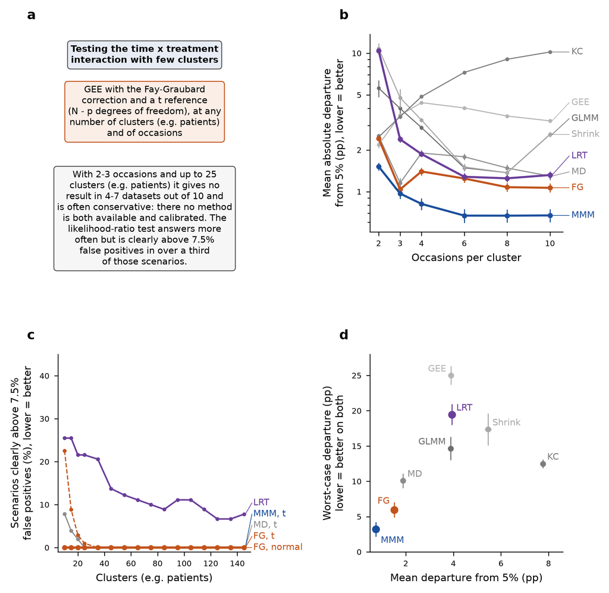

Figura 1. Errore di I tipo del test sull’interazione tempo x trattamento; modello marginalizzato multilivello (MMM) con controllo di convergenza negli scenari M3-M5 (Il modello marginalizzato si analizza con un controllo di convergenza negli scenari con pendenza della deviazione standard latente (D-32)). (a) Regola raccomandata (proposta, in attesa della scelta del PI); N = numero di cluster (per esempio pazienti), p = numero di coefficienti della media. (b) Deviazione assoluta media dal 5% nominale, in punti percentuali, per numero di occasioni per cluster; media su scenari M1-M5, numeri di cluster e tre meccanismi di generazione; asse logaritmico; barre = stima +/- 2 MCSE (per blocchi, S5). (c) Percentuale di punti di disegno (griglia principale e M1c, tutte le lunghezze di serie) in cui la strategia supera chiaramente il 7,5% di falsi positivi, per numero di cluster. Chiaramente sopra = tasso di rifiuto - 2 MCSE > 7,5%, con MCSE binomiale del punto di disegno (radice di p(1 - p)/n, n = replicati usabili); i punti con meno di 20 replicati usabili non sono valutati. FG = GEE con correzione di Fay-Graubard, MD = Mancl-DeRouen, t = riferimento t con N - p gradi di liberta’, normale = riferimento normale; LRT = rapporto di verosimiglianza sul modello misto. (d) Deviazione nel caso peggiore contro deviazione media dal 5%, sui dati GenBinaryY: tasso di rifiuto aggregato sui cinque scenari in ciascuna delle 96 combinazioni di N e T, poi massimo e media dello scarto da 5; barre = stima +/- 2 MCSE.

Cosa guardare: nel pannello c la linea arancione piena (Fay-Graubard con la t) resta a zero a ogni N; la tratteggiata (stessa correzione con la normale) e’ al 22% a 10 cluster.

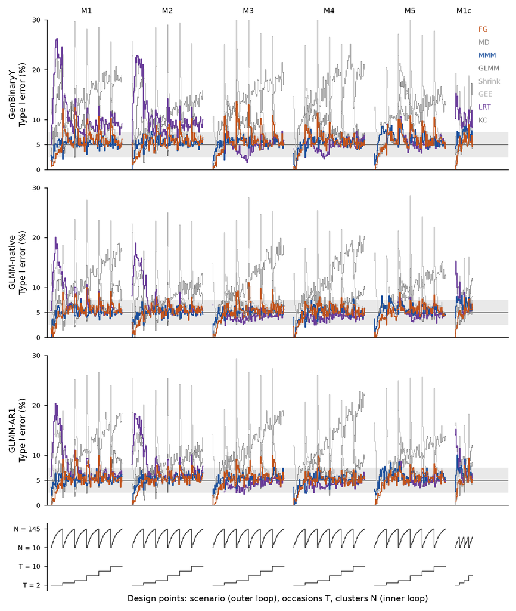

Figura 2. Errore di I tipo in ogni punto di disegno (nested-loop plot); MMM con controllo di convergenza in M3-M5. Un valore per punto di disegno, ordinati per scenario (ciclo esterno), poi numero di occasioni T, poi numero di cluster N (per esempio pazienti) (ciclo interno, pannello in basso); le tre righe sono i meccanismi di generazione; a destra lo scenario ancorato alla coorte (M1c). Banda grigia: 2,5-7,5% (criterio di Bradley); linea: 5% nominale. In colore: FG = GEE con Fay-Graubard e riferimento t, MMM = modello marginalizzato multilivello, LRT = rapporto di verosimiglianza sul modello misto; in grigio gli altri metodi. Non disegnati i punti con meno di 20 replicati usabili; asse troncato al 30% (4 valori sopra).

Punti non disegnati (meno di 20 replicati usabili): 571 su 12096; valori sopra il 30% troncati: 4.

Cosa guardare: il GEE senza correzione e Kauermann-Carroll (grigi) escono dalla banda a ogni ciclo di N; il LRT (viola) esce in alto a T = 2-3 in M1-M2 e in M1c; MMM (blu), con il controllo di convergenza, resta nella banda anche in M3-M5 con serie lunghe; nella versione dello studio (Figura S3, appendice A5) ne usciva in alto in M3-M5 a T >= 8.

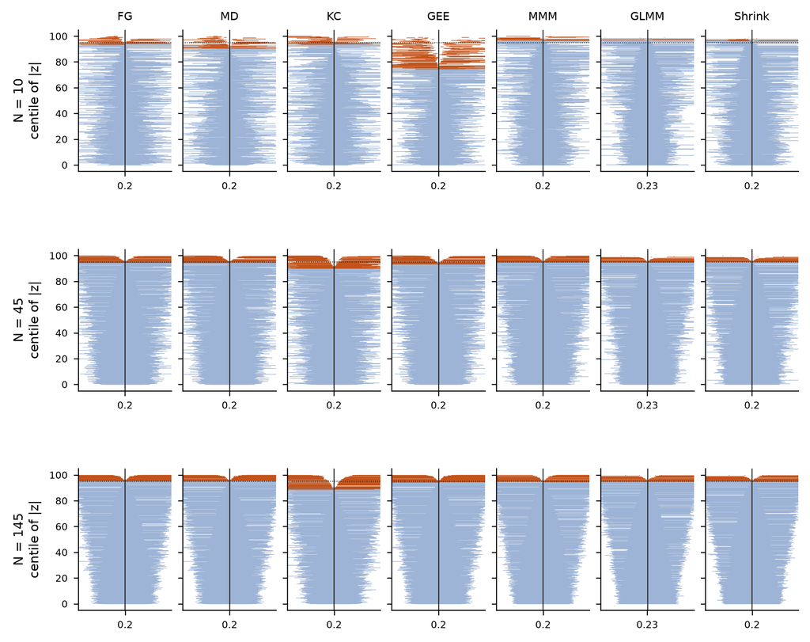

Figura S1 (supplemento). Zip plot degli intervalli di confidenza al 95% per l’interazione tempo x trattamento: dati GLMM-native, scenario M1, T = 4, ipotesi alternativa; righe = numero di cluster (10, 45, 145), colonne = metodi. Ogni linea orizzontale e’ l’intervallo di un replicato, ordinati per centile di |z| = |stima - valore vero| / SE; linea verticale = valore vero; arancione = l’intervallo non contiene il valore vero; linea punteggiata = 95%; banda grigia = copertura stimata con il suo intervallo Monte Carlo al 95%.

## 3. Dubbi aperti durante il lavoro e come si sono chiusi

   *Causa.* `MMLB::mm` esponenzia ogni coefficiente della deviazione standard latente: con `lv.formula = ~time` la deviazione standard vale exp(a0) + exp(a1) t, quindi la pendenza e’ forzata positiva e il valore 0 e’ il bordo dello spazio dei parametri (a1 -> -infinito). In tutti e tre i generatori la pendenza vera e’ circa 0,01 per occasione: in M3 e M4 la deviazione standard latente e’ 1 + 0,01 t (GenBinaryY) o quella di un’intercetta e pendenza casuali con varianza della pendenza 0,001 (GLMM-native e GLMM-AR1); in M5 c’e’ anche una pendenza per la dose. Il valore vero sta quindi vicino al bordo, e in molti dataset il massimo della verosimiglianza e’ sul bordo. (Avevo letto prima a1 come pendenza su scala logaritmica e concluso che la variabile latente spariva: era sbagliato. La pendenza stimata exp(a1) ha mediana 0,08-0,13 nei tre scenari, 0,05-0,06 nei fit che convergono, e quartili da circa 0 a circa 1: e’ stimata con grande incertezza attorno a un valore vero vicino a 0.)

   *Cosa succede ai fit.* Con T >= 8, `nlm` non dichiara convergenza (codici 2-5) nel 41% dei fit in M3, 65% in M4, 97% in M5 (`tables/V4_S6_mmm_mech_codes.csv`). I codici non pesano allo stesso modo. Il codice 4 (limite di 100 iterazioni) e’ innocuo: rifatti con 2.000 iterazioni, convergono in mediana dopo 105-140 iterazioni e la stima dell’interazione non cambia, ne’ i rifiuti (`tables/V4_S6_mmm_iterlim.csv`). Il danno viene da due modi di guasto. *Stima spostata* (codice 5, “passo massimo superato”, la funzione tende a un asintoto in qualche direzione; 10-26% dei fit): l’SE e’ giusto, uguale a quello del fit senza pendenza sullo stesso dataset, ma la stima si allontana dal massimo. *SE crollato* (codici 2-3, 4,1-10,4%): la stima e’ giusta, l’SE e’ meno della meta’ di quello del fit senza pendenza.

   *Perche’ peggiora con N.* Con T >= 8 lo spostamento assoluto della stima nei fit con codice 5 non dipende da N (90esimo percentile 0,20-0,29 su tutte le celle), mentre l’errore standard dell’interazione scende da 0,28-0,34 (N = 10) a 0,053-0,064 (N = 145). Lo stesso spostamento vale quindi meno di 1 errore standard a N = 10 e 3,4-5,3 errori standard a N = 145, e i rifiuti dentro quei fit salgono da 3-8% a 34-45% (`tables/V4_S6_mmm_modes_disp_T8.csv`). In M3 i fit convergenti restano tarati a ogni N (5,9% a N = 25, 5,6% a N = 145), i non convergenti no (5,8% e 11,9%) (`tables/V4_S6_mmm_mech_conv.csv`).

   *Perche’ peggiora con T.* Non perche’ i guasti siano piu’ frequenti: a N >= 25 la quota di fit con codice 5 da T = 4 a T = 10 va 14 -> 8 -> 7 -> 9% in M3, 26 -> 11 -> 11 -> 12% in M4, 43 -> 26 -> 23 -> 21% in M5. Cresce invece il loro peso, per la stessa ragione di N: l’errore standard dell’interazione tempo x trattamento si restringe con serie piu’ lunghe, lo spostamento no; i rifiuti dentro quei fit vanno 10 -> 8 -> 12 -> 30% in M3, 6 -> 9 -> 16 -> 27% in M4, 8 -> 12 -> 16 -> 24% in M5 (`tables/V4_S6_mmm_modes.csv`). Non ho spiegato perche’ i guasti siano piu’ frequenti a T = 2-4.

   *Prova per intervento.* Sugli stessi dataset, il modello senza i termini di pendenza della deviazione standard latente (`lv.formula = ~1`) da’ rifiuti fra 4,4 e 6,5% nelle nove combinazioni scenario x meccanismo con T >= 8 (studio: 6,2-10,4%). La regola registrata prima del calcolo (P8: se `nlm` non converge o la pendenza stimata e’ sotto 0,001, si usa il fit senza pendenza) non e’ chiaramente sopra 7,5% in nessuna delle 180 celle (con il fit dello studio: 7); 12 celle sono chiaramente sotto 2,5%, tutte con N = 10-25 e T = 2, come per gli altri metodi (`tables/V4_S6_mmm_rule_P8_cells.csv`). La regola funziona qui perche’ la pendenza vera e’ circa 0; quanto valga con una pendenza vera grande, il disegno non lo dice.

   *Attese.* P5 smentita: anche nei fit non al bordo il tasso supera la banda in M4-M5, perche’ il criterio “al bordo” includeva il codice 4, innocuo, e non separava i due modi di guasto. P6 smentita: la quota di fit al bordo scende con N in 27 delle 45 combinazioni. P7 smentita: in M1, senza pendenza, i fit non convergenti sono 8,87%; le celle fuori banda sono quasi tutte prudenti a N = 10-25. P8 confermata. (`tables/V4_S6_mmm_bnd_preds.csv`)

   *Correzione.* Su decisione del PI, MMM in M3-M5 e’ stato rianalizzato su tutti i dataset con la regola di ricaduta; risultati nella sezione 1, “Rianalisi di MMM con controllo di convergenza”. Il PI ha escluso di presentare il problema come limite del software.

## 4. Cosa e’ girato

| file | md5 |
| --- | --- |
| results_v4/S6/s6_boot.rds | 0bd49f813c41eea5f41ec7ec1dddb969 |
| results_v4/S6/s6_boot_m1c_boby.rds | 3475657238754b870a82f52b9b24bc34 |
| tables/V4_S6_values.csv | cf97c1b0e136fb3628cee2ffd32d79cd |
| tables/V4_S6_m1c_claims.csv | 73ac234a9851968e77a77c35e9e001e8 |
| tables/V4_S6_table_cells.csv | 19a1f2ba9feee2989710567e38190fc7 |
| reports/morris/S6_tables.md | 4f06deffd51826f81761cf159b059856 |
| tables/V4_S6_nestedloop.csv | 7e8a8305b20681ca0b5ad55e72611aab |
| tables/V4_S6_zip.csv | fa73919493509c4463b980d519a1c66d |
| tables/V4_S6_rule_branches.csv | 2c5802944cb55b75c70d6a85a6edb8dc |
| reports/morris/S6_figures/S6_figures_data.csv | fc1795e9036bfa6e932c9e24e3d3e9b8 |
| results_v4/S6/mmm_boundary_GenBinaryY.rds | 89c8e70ec988dfdc47d6c51f5ee64fe5 |
| results_v4/S6/mmm_boundary_GLMM-native.rds | 98340da0827270bbc1cecc04e0178142 |
| results_v4/S6/mmm_boundary_GLMM-AR1.rds | 7093ba6ddd2a4b79c6d13ffdfc32d80e |
| results_v4/S6/mmm_iterlim_GenBinaryY.rds | bd07500208fb087d382414e9454092f6 |
| results_v4/S6/mmm_iterlim_GLMM-native.rds | ee4f5ae46370f8806cf4b5e54f8889f0 |
| results_v4/S6/mmm_iterlim_GLMM-AR1.rds | c271c2c1093f35d73f11f5f8a453465a |
| tables/V4_S6_mmm_bnd_preds.csv | 2fbed2e6a07ccfa76cf0e92c9ed52956 |
| tables/V4_S6_mmm_rule_P8_cells.csv | 3f901fa52efcfb1eb832f3719aaf3435 |

Script (ramo `morris-v4`): `R/s6/s6_run.R` (motore di S5 e quantita’ aggiuntive su 2.001 replicati bootstrap, 3,6 minuti con 45 processi), `R/s6/s6_run_boby.R` (sensibilita’ bobyqa su M1c, 3,2 minuti), `R/s6/s6_checks.R` (G2, G5, classificazione di M1c, previsioni), `R/s6/s6_tables.R`, `R/s6/s6_figdata.R`, `R/s6/s6_rule.R`, `R/s6/s6_m1c_reasons.R`, `R/s6/s6_m1c_glmer_extreme.R`, `R/s6/s6_check_g3.R`, `py/s6/s6_figures.py` (stile `tools/s6_figure.mplstyle`), `R/s6/s6_g1.sh`. Diagnostica di MMM (post hoc, su replicati esistenti rigenerati con il loro seme): `R/s6/s6_mmm_diag.R`, `s6_mmm_tail.R`, `s6_mmm_se_probe.R` (+ `_sum`), `s6_mmm_outlier.R`, `s6_mmm_boundary.R` (48.000 dataset, 3 processi da 33 core, circa 8 minuti) e `s6_mmm_boundary_sum.R`, `s6_mmm_mechanism.R`, `s6_mmm_iterlim.R` (+ `_sum`), `s6_mmm_modes.R`. Rianalisi con controllo di convergenza: `R/s6/s6_mmm_cc_run.R` (17.280 blocchi, circa 4,4 ore con 50 processi), `R/s6/s6cc_build.R` (G8-G10 e righe della variante), `R/s6/s6cc_pipeline.sh` (catena S4-S6 con `MMM_VARIANT=cc`), `R/s6/s6cc_compare.R` (P9-P12 e integrita’), `R/s6/s6cc_claims_diff.R`. Il test di parita’ H0/H1 non si applica: lo step non genera dati nuovi. Decisione tecnica: Regole tecniche di tabelle e figure (D-28).

## Appendice

### A1. Affermazioni nello scenario M1c

| sotto_affermazione | stima | intervallo | margine | classe_M1c | classe_griglia | bobyqa | n_req |
| --- | --- | --- | --- | --- | --- | --- | --- |
| C01\|AR1 | -1,73 | [-2,73; -0,95] | 1.0 | smentita | trascurabile |  |  |
| C01\|GB | -1,22 | [-2,22; -0,57] | 1.0 | smentita | risolta e rilevante |  |  |
| C01\|NAT | -1,24 | [-2,38; -0,77] | 1.0 | smentita | trascurabile |  |  |
| C02\|AR1 | 0,26 | [-0,04; 0,35] | 1.0 | trascurabile | trascurabile |  |  |
| C02\|GB | 0,25 | [-0,00; 0,40] | 1.0 | trascurabile | trascurabile |  |  |
| C02\|NAT | 0,18 | [-0,02; 0,35] | 1.0 | trascurabile | trascurabile |  |  |
| C03\|AR1 | 1,93 | [1,62; 2,23] | 1.0 | risolta e rilevante | risolta, rilevanza indeterminata |  |  |
| C03\|GB | 1,83 | [1,51; 2,16] | 1.0 | risolta e rilevante | trascurabile |  |  |
| C03\|NAT | 1,78 | [1,48; 2,08] | 1.0 | risolta e rilevante | trascurabile |  |  |
| C03b\|AR1 | 1,74 | [1,44; 2,04] | 1.0 | risolta e rilevante | trascurabile |  |  |
| C03b\|GB | 1,64 | [1,33; 1,96] | 1.0 | risolta e rilevante | trascurabile |  |  |
| C03b\|NAT | 1,50 | [1,21; 1,80] | 1.0 | risolta e rilevante | trascurabile |  |  |
| C06a\|all | -1,02 | [-1,46; -0,54] | 1.0 | smentita | trascurabile |  |  |
| C06b\|all | 0,29 | [-0,00; 0,41] | 1.0 | trascurabile | trascurabile |  |  |
| C06c\|all | -0,29 | [-0,43; -0,10] | 1.0 | smentita | trascurabile |  |  |
| C06d\|all | 0,04 | [-0,39; 0,60] | 1.0 | confermata | confermata |  |  |
| C08\|mad | 0,62 | [0,55; 0,74] | NA | indeterminata | confermata |  |  |
| C08\|madcell | 0,71 | [0,55; 0,86] | NA | indeterminata | confermata |  |  |
| C08\|rate | 0,62 | [0,55; 0,79] | NA | indeterminata | confermata |  |  |
| C08\|wc | 0,86 | [0,60; 0,90] | NA | indeterminata | confermata |  |  |
| C09\|all | 0,20 | [0,13; 0,53] | 1.0 | confermata | confermata |  |  |
| C09\|rank_mad_identical | 0,00 | [0,00; 1,00] | 1.0 | descrittiva | descrittiva |  |  |
| C09\|rank_wc_identical | 0,00 | [0,00; 1,00] | 1.0 | descrittiva | descrittiva |  |  |
| C10a\|BH | 56,94 | [55,38; 61,63] | NA | descrittiva | descrittiva |  |  |
| C10a\|BY | 46,88 | [44,79; 51,39] | NA | descrittiva | descrittiva |  |  |
| C10a\|bonferroni | 34,90 | [33,33; 38,89] | NA | descrittiva | descrittiva |  |  |
| C10a\|ncells | 576,00 | [576,00; 576,00] | NA | descrittiva | descrittiva |  |  |
| C10a\|raw | 60,94 | [59,38; 65,45] | NA | descrittiva | descrittiva |  |  |
| C10b\|BH | -1,39 | [-8,33; 8,33] | 5.0 | non risolta | risolta, rilevanza indeterminata |  | 34.769 |
| C10b\|BY | -5,56 | [-6,94; 5,59] | 5.0 | non risolta | risolta, rilevanza indeterminata |  | 1.497 |

[output cut: 100 more lines]

Non applicabili o escluse: C04|all (conteggio delle celle vinte fuori dal manoscritto (D-25)); C05 (conteggio delle celle vinte fuori dal manoscritto (D-25)); C07|all (usa T = 10, assente in M1c); C12b|GB (usa N = 145, assente in M1c); C13a|all (usa gli scenari M3-M5, assenti in M1c); C13b (riga non calcolata anche in S5); C18 (riga non calcolata anche in S5); C21b (riga non calcolata anche in S5); C24b|all (usa N = 145, assente in M1c); C25a|AR1 (usa N >= 55, assente in M1c); C25a|NAT (usa N >= 55, assente in M1c); C25b|AR1 (usa N >= 55, assente in M1c); C25b|GB (usa N >= 55, assente in M1c); C25b|NAT (usa N >= 55, assente in M1c); C25c|AR1|gee_fg (usa N >= 55, assente in M1c); C25c|AR1|gee_md (usa N >= 55, assente in M1c); C25c|GB|gee_fg (usa N >= 55, assente in M1c); C25c|GB|gee_md (usa N >= 55, assente in M1c); C25c|NAT|gee_fg (usa N >= 55, assente in M1c); C25c|NAT|gee_md (usa N >= 55, assente in M1c); C26 (riga non calcolata anche in S5); C27 (riga non calcolata anche in S5); C28 (riga non calcolata anche in S5); C29 (riga non calcolata anche in S5).

| classe | N |
| --- | --- |
| trascurabile | 31 |
| smentita | 23 |
| risolta e rilevante | 20 |
| descrittiva | 13 |
| non risolta | 12 |
| confermata | 7 |
| smentita e rilevante | 6 |
| vedi tabella dei punti di cambio | 6 |
| indeterminata | 5 |
| risolta, rilevanza indeterminata | 5 |
| risolta | 2 |

### A2. Tabelle v4

Tutte le tabelle, griglia principale e M1c, con le MCSE: `S6_tables.md` (generato da `R/s6/s6_tables.R`).

Generated by `R/s6/s6_tables.R` from `tables/V4_S6_values.csv`; every entry is listed with its source in `tables/V4_S6_table_cells.csv`.

### T3. Type I error at the nominal 5% (%) (main grid, 1,440 design points)

| Method | rate GB | rate NAT | rate AR1 | worst GB | worst NAT | worst AR1 | MAD GB | MAD NAT | MAD AR1 |
| --- | --- | --- | --- | --- | --- | --- | --- | --- | --- |
| GEE, Fay-Graubard | 5.83 | 5.32 | 5.34 | 4.7 (0.2) | 2.8 (0.2) | 2.9 (0.2) | 1.04 | 0.52 | 0.55 |
| GEE, Mancl-DeRouen | 6.09 | 5.51 | 5.56 | 8.6 (0.3) | 5.9 (0.2) | 6.0 (0.2) | 1.47 | 0.88 | 0.95 |
| Marginalized model | 6.56 | 6.19 | 6.41 | 2.2 (0.2) | 1.5 (0.1) | 1.6 (0.09) | 1.59 | 1.20 | 1.41 |
| GLMM, Wald | 8.61 | 6.30 | 6.55 | 4.5 (0.1) | 1.8 (0.1) | 2.2 (0.1) | 3.48 | 1.38 | 1.58 |
| Shrinkage GLM | 9.28 | 6.64 | 6.91 | 4.9 (0.1) | 2.3 (0.1) | 2.4 (0.1) | 4.20 | 1.61 | 1.85 |
| GEE, uncorrected | 8.35 | 7.61 | 7.70 | 21.0 (0.3) | 17.4 (0.3) | 18.3 (0.3) | 3.85 | 3.00 | 3.12 |
| GLMM, likelihood ratio | 7.80 | 5.77 | 6.14 | 3.6 (0.2) | 1.8 (0.2) | 1.8 (0.1) | 2.80 | 0.77 | 1.14 |
| GEE, Kauermann-Carroll | 13.12 | 10.43 | 10.72 | 9.2 (0.1) | 6.5 (0.2) | 6.7 (0.1) | 7.95 | 5.32 | 5.58 |

*Rejection rate pooled over the grid, own usable replicates (usability U0). The rate is replicate-weighted within each cluster count; the worst case is the largest absolute departure from 5 over the cluster counts and MAD their mean. GB = GenBinaryY, NAT = GLMM-native, AR1 = GLMM-AR1. Monte Carlo SE (block bootstrap, B = 2000): at most 0.06 for rate GB; 0.05 for rate NAT; 0.05 for rate AR1; 0.06 for MAD GB; 0.05 for MAD NAT; 0.05 for MAD AR1. Where an entry carries a value in parentheses, it is its Monte Carlo SE.*

### T4. Mean absolute departure from 5% by number of occasions (percentage points) (main grid, 1,440 design points)

| Method | T = 2 | T = 3 | T >= 4 |
| --- | --- | --- | --- |
| GEE, Fay-Graubard | 2.4 (0.04) | 1.0 (0.05) | 1.20 |
| GEE, Mancl-DeRouen | 2.5 (0.03) | 1.2 (0.05) | 1.62 |
| Marginalized model | 1.8 (0.05) | 1.5 (0.05) | 1.75 |
| GLMM, Wald | 5.6 (0.4) | 4.0 (0.3) | 2.09 |
| Shrinkage GLM | 10.8 (0.5) | 4.8 (0.4) | 2.19 |
| GEE, uncorrected | 2.2 (0.06) | 3.6 (0.06) | 3.79 |
| GLMM, likelihood ratio | 10.4 (0.2) | 2.4 (0.06) | 1.43 |
| GEE, Kauermann-Carroll | 2.5 (0.05) | 3.5 (0.06) | 7.84 |

*Cell-weighted mean over design points and mechanisms. The last column pools T = 4, 6, 8, 10. Monte Carlo SE (block bootstrap, B = 2000): at most 0.04 for T >= 4. Where an entry carries a value in parentheses, it is its Monte Carlo SE.*

### T5. Method-cells detectably off nominal (%) (main grid, 1,440 design points)

| Method | BH | BY |
| --- | --- | --- |
| GEE, Fay-Graubard | 23 (0.8) | 14.2 |
| GEE, Mancl-DeRouen | 28 (1) | 20.3 |
| Marginalized model | 29 (0.9) | 22.6 |
| GLMM, Wald | 51 (0.9) | 41.9 |
| Shrinkage GLM | 53 (0.8) | 45.1 |
| GEE, uncorrected | 46 (0.9) | 34.6 |
| GLMM, likelihood ratio | 35 (1) | 28.0 |
| GEE, Kauermann-Carroll | 87 (0.5) | 79.8 |

*Exact binomial test of each method-cell with at least one usable replicate against 5%, false discovery rate controlled within method at 5% by Benjamini-Hochberg (BH) or Benjamini-Yekutieli (BY). Monte Carlo SE (block bootstrap, B = 2000): at most 0.8 for BY. Where an entry carries a value in parentheses, it is its Monte Carlo SE.*

### T6. Type I error on each method’s own replicates and on the common set (%) (main grid, 1,440 design points)

| Method | own GB | own NAT | own AR1 | common GB | common NAT | common AR1 | shift GB | shift NAT | shift AR1 |
| --- | --- | --- | --- | --- | --- | --- | --- | --- | --- |
| GEE, Fay-Graubard | 5.83 | 5.32 | 5.34 | 5.76 | 5.44 | 5.43 | -0.06 (0.01) | 0.12 (0.01) | 0.08 (0.01) |
| GEE, Mancl-DeRouen | 6.09 | 5.51 | 5.56 | 6.06 | 5.66 | 5.68 | -0.03 (0.01) | 0.15 (0.01) | 0.12 (0.01) |
| Marginalized model | 6.56 | 6.19 | 6.41 | 6.24 | 6.02 | 6.25 | -0.33 (0.02) | -0.17 (0.01) | -0.16 (0.01) |
| GLMM, Wald | 8.61 | 6.30 | 6.55 | 8.59 | 6.29 | 6.56 | -0.03 (0.006) | -0.01 (0.005) | 0.00 (0.005) |
| Shrinkage GLM | 9.28 | 6.64 | 6.91 | 8.59 | 6.29 | 6.56 | -0.70 (0.01) | -0.35 (0.01) | -0.35 (0.01) |
| GEE, uncorrected | 8.35 | 7.61 | 7.70 | 7.80 | 7.42 | 7.44 | -0.54 (0.02) | -0.19 (0.02) | -0.26 (0.02) |
| GLMM, likelihood ratio | 7.80 | 5.77 | 6.14 | 6.83 | 4.96 | 5.33 | -0.97 (0.02) | -0.81 (0.02) | -0.81 (0.02) |
| GEE, Kauermann-Carroll | 13.12 | 10.43 | 10.72 | 13.55 | 10.94 | 11.19 | 0.43 (0.02) | 0.51 (0.02) | 0.47 (0.02) |

*Common set: the replicates on which all eight methods returned a usable result. Shift = common minus own, in percentage points. Monte Carlo SE (block bootstrap, B = 2000): at most 0.06 for own GB; 0.05 for own NAT; 0.05 for own AR1; 0.06 for common GB; 0.06 for common NAT; 0.06 for common AR1. Where an entry carries a value in parentheses, it is its Monte Carlo SE.*

### T7. Replicates returning a usable result, by number of occasions (%) (main grid, 1,440 design points)

| Structure, occasions | GEE, Fay-Graubard | GEE, Mancl-DeRouen | Marginalized model | GLMM, Wald | Shrinkage GLM | GEE, uncorrected | GLMM, likelihood ratio | GEE, Kauermann-Carroll |
| --- | --- | --- | --- | --- | --- | --- | --- | --- |
| random intercept, T = 2 | 72.7 (0.1) | 72.7 (0.1) | 68.2 (0.1) | 68.6 (0.1) | 74.0 (0.1) | 78.7 (0.1) | 98.93 (0.03) | 72.6 (0.1) |
| random intercept, T = 3 | 88.3 (0.09) | 88.3 (0.09) | 87.1 (0.1) | 87.8 (0.09) | 88.9 (0.09) | 91.7 (0.08) | 99.64 (0.02) | 88.3 (0.09) |
| random intercept, T = 4 | 93.8 (0.07) | 93.7 (0.07) | 92.9 (0.08) | 93.7 (0.07) | 94.1 (0.07) | 95.9 (0.06) | 99.86 (0.01) | 93.7 (0.07) |
| random intercept, T = 6 | 97.7 (0.05) | 97.6 (0.05) | 97.4 (0.05) | 97.8 (0.05) | 97.9 (0.05) | 98.6 (0.04) | 99.98 (0.004) | 97.7 (0.05) |
| random intercept, T = 8 | 98.9 (0.04) | 98.8 (0.04) | 98.9 (0.04) | 99.0 (0.03) | 99.0 (0.03) | 99.4 (0.03) | 100.00 (0.001) | 98.8 (0.04) |
| random intercept, T = 10 | 99.5 (0.03) | 99.4 (0.03) | 99.5 (0.02) | 99.6 (0.02) | 99.6 (0.02) | 99.7 (0.02) | 100.00 (0) | 99.4 (0.03) |
| random slopes, T = 2 | 73.1 (0.08) | 73.1 (0.08) | 67.6 (0.1) | 0.0 (0.001) | 0.0 (0.004) | 78.8 (0.09) | 0.14 (0.02) | 73.1 (0.08) |
| random slopes, T = 3 | 88.4 (0.07) | 88.4 (0.07) | 86.8 (0.08) | 56.7 (0.07) | 59.3 (0.06) | 91.8 (0.06) | 66.47 (0.02) | 88.4 (0.07) |
| random slopes, T = 4 | 94.1 (0.06) | 94.0 (0.06) | 92.9 (0.06) | 90.8 (0.07) | 93.7 (0.07) | 96.1 (0.05) | 99.41 (0.04) | 94.0 (0.06) |
| random slopes, T = 6 | 98.0 (0.04) | 97.9 (0.04) | 97.0 (0.05) | 97.7 (0.04) | 98.1 (0.04) | 98.8 (0.03) | 99.98 (0.003) | 97.9 (0.04) |
| random slopes, T = 8 | 99.1 (0.03) | 99.0 (0.03) | 98.2 (0.04) | 99.2 (0.02) | 99.2 (0.02) | 99.5 (0.02) | 100.00 (0.001) | 99.1 (0.03) |
| random slopes, T = 10 | 99.5 (0.02) | 99.4 (0.02) | 98.1 (0.04) | 99.6 (0.02) | 99.6 (0.02) | 99.7 (0.01) | 100.00 (0.0007) | 99.5 (0.02) |

*Pooled over mechanisms and cluster counts, every design point in the denominator. Random intercept only: scenarios M1-M2; random slopes: M3-M5. Where an entry carries a value in parentheses, it is its Monte Carlo SE.*

### T8. Usable result and unconditional validity at 20 clusters or fewer (%) (main grid, 1,440 design points)

| Method | usable | unconditional validity | design points with a usable replicate |
| --- | --- | --- | --- |
| GEE, Fay-Graubard | 68.95 (0.09) | 63.8 | 270 |
| GEE, Mancl-DeRouen | 68.66 (0.1) | 62.3 | 270 |
| Marginalized model | 66.48 (0.09) | 62.2 | 270 |
| GLMM, Wald | 64.46 (0.08) | 61.0 | 244 |
| Shrinkage GLM | 66.86 (0.08) | 62.6 | 251 |
| GEE, uncorrected | 78.72 (0.08) | 65.2 | 270 |
| GLMM, likelihood ratio | 85.82 (0.03) | 79.9 | 255 |
| GEE, Kauermann-Carroll | 68.70 (0.09) | 62.2 | 270 |

*Means over design points at N <= 20, pooled over mechanisms and scenarios, cells a method never fits counted at zero. Unconditional validity = probability of a usable result that does not falsely reject. Monte Carlo SE (block bootstrap, B = 2000): at most 0.2 for unconditional validity. Where an entry carries a value in parentheses, it is its Monte Carlo SE.*

### T9. Mean absolute departure from 5% by estimability stratum (percentage points) (main grid, 1,440 design points)

| Method | <50% | 50-80% | 80-95% | 95-99.9% | 100% |
| --- | --- | --- | --- | --- | --- |
| GEE, Fay-Graubard | 4 (0.1) | 2.8 (0.09) | 2.8 (0.08) | 1.15 (0.03) | 0.63 (0.02) |
| GEE, Mancl-DeRouen | 4 (0.1) | 4.2 (0.1) | 4.2 (0.1) | 1.34 (0.04) | 0.61 (0.02) |
| Marginalized model | 3 (0.1) | 1.6 (0.08) | 2.0 (0.08) | 2.31 (0.04) | 1.05 (0.03) |
| GLMM, Wald | 5 (1) | 3.4 (0.6) | 2.5 (0.1) | 2.67 (0.06) | 2.43 (0.04) |
| Shrinkage GLM | 10 (1) | 6.5 (0.9) | 3.9 (0.1) | 2.95 (0.06) | 2.44 (0.04) |
| GEE, uncorrected | 8 (0.2) | 9.9 (0.2) | 8.8 (0.2) | 2.83 (0.06) | 1.04 (0.03) |
| GLMM, likelihood ratio | 5 (0.3) | 5.2 (0.2) | 4.9 (0.2) | 2.37 (0.06) | 1.27 (0.03) |
| GEE, Kauermann-Carroll | 3 (0.1) | 1.9 (0.09) | 3.1 (0.09) | 6.15 (0.08) | 8.14 (0.06) |
| design points | 83 | 100 | 147 | 495 | 615 |

*Design points stratified by the mean usable proportion of the five marginal methods (right-closed strata). The last row gives the design points per stratum. Where an entry carries a value in parentheses, it is its Monte Carlo SE.*

### T10. Raw and size-adjusted power at the interaction contrast (%) (main grid, 1,440 design points)

| Mechanism, method | raw | size-adjusted |
| --- | --- | --- |
| GenBinaryY, GEE, Fay-Graubard | 23.30 | 22.0 (0.08) |
| GenBinaryY, GEE, Mancl-DeRouen | 23.53 | 21.9 (0.08) |
| GenBinaryY, Marginalized model | 24.56 | 21.9 (0.09) |
| GenBinaryY, GLMM, Wald | 31.91 | 24.2 (0.1) |
| GenBinaryY, Shrinkage GLM | 32.15 | 23.6 (0.1) |
| GenBinaryY, GEE, uncorrected | 26.22 | 21.5 (0.08) |
| GenBinaryY, GLMM, likelihood ratio | 30.12 | 26.4 (0.09) |
| GenBinaryY, GEE, Kauermann-Carroll | 34.57 | 23.0 (0.08) |
| GLMM-native, GEE, Fay-Graubard | 23.73 | 23.1 (0.08) |
| GLMM-native, GEE, Mancl-DeRouen | 23.89 | 23.1 (0.08) |
| GLMM-native, Marginalized model | 24.74 | 22.7 (0.09) |
| GLMM-native, GLMM, Wald | 27.98 | 23.5 (0.3) |
| GLMM-native, Shrinkage GLM | 28.14 | 23.2 (0.3) |
| GLMM-native, GEE, uncorrected | 26.51 | 22.8 (0.08) |
| GLMM-native, GLMM, likelihood ratio | 26.77 | 26.3 (0.09) |
| GLMM-native, GEE, Kauermann-Carroll | 31.94 | 24.1 (0.08) |
| GLMM-AR1, GEE, Fay-Graubard | 24.15 | 23.5 (0.08) |
| GLMM-AR1, GEE, Mancl-DeRouen | 24.36 | 23.4 (0.08) |
| GLMM-AR1, Marginalized model | 25.54 | 23.0 (0.09) |
| GLMM-AR1, GLMM, Wald | 29.16 | 25.4 (0.2) |
| GLMM-AR1, Shrinkage GLM | 29.31 | 25.0 (0.2) |
| GLMM-AR1, GEE, uncorrected | 27.00 | 23.0 (0.08) |
| GLMM-AR1, GLMM, likelihood ratio | 27.92 | 26.7 (0.09) |
| GLMM-AR1, GEE, Kauermann-Carroll | 32.69 | 24.5 (0.08) |

*Pooled by mechanism. Size-adjusted: each cell’s own empirical 5% critical value from the null arm (for the likelihood-ratio test on the p-value scale). Monte Carlo SE (block bootstrap, B = 2000): at most 0.07 for raw. Where an entry carries a value in parentheses, it is its Monte Carlo SE.*

### T11. Type I error under a normal and a t reference (%) (main grid, 1,440 design points)

| Method | normal GB | normal NAT | normal AR1 | t GB | t NAT | t AR1 | shift GB | shift NAT | shift AR1 | shift at N <= 25 |
| --- | --- | --- | --- | --- | --- | --- | --- | --- | --- | --- |
| GEE, Fay-Graubard | 5.83 | 5.32 | 5.34 | 5.06 | 4.58 | 4.63 | -0.77 | -0.75 | -0.71 | 2.19 |
| GEE, Mancl-DeRouen | 6.09 | 5.51 | 5.56 | 5.26 | 4.73 | 4.80 | -0.83 | -0.78 | -0.76 | 2.44 |
| Marginalized model | 6.56 | 6.19 | 6.41 | 5.76 | 5.39 | 5.60 | -0.81 | -0.80 | -0.81 | 2.31 |
| GLMM, Wald | 8.61 | 6.30 | 6.55 | 7.96 | 5.77 | 5.99 | -0.65 | -0.53 | -0.57 | 1.39 |
| Shrinkage GLM | 9.28 | 6.64 | 6.91 | 8.60 | 6.10 | 6.33 | -0.69 | -0.55 | -0.58 | 1.47 |
| GEE, uncorrected | 8.35 | 7.61 | 7.70 | 7.21 | 6.49 | 6.56 | -1.14 | -1.12 | -1.14 | 3.72 |
| GEE, Kauermann-Carroll | 13.12 | 10.43 | 10.72 | 12.02 | 9.45 | 9.74 | -1.10 | -0.98 | -0.98 | 2.71 |

*t reference with N - p degrees of freedom. Shift = t minus normal, percentage points; the last column is normal minus t pooled over mechanisms at N <= 25 (a positive value: the t reference rejects less). Monte Carlo SE (block bootstrap, B = 2000): at most 0.06 for normal GB; 0.05 for normal NAT; 0.05 for normal AR1; 0.06 for t GB; 0.05 for t NAT; 0.05 for t AR1; 0.02 for shift GB; 0.02 for shift NAT; 0.02 for shift AR1; 0.04 for shift at N <= 25.*

### T12. Coverage of the 95% confidence interval (%) (main grid, 1,440 design points)

| Method | GenBinaryY | GLMM-native | GLMM-AR1 |
| --- | --- | --- | --- |
| GEE, Fay-Graubard | 94.55 | 94.92 | 94.92 |
| GEE, Mancl-DeRouen | 94.24 | 94.67 | 94.65 |
| Marginalized model | 93.17 | 93.38 | 93.23 |
| GLMM, Wald | n.a. | 93.51 | 93.17 |
| Shrinkage GLM | 90.06 | 92.88 | 92.60 |
| GEE, uncorrected | 91.90 | 92.53 | 92.47 |
| GEE, Kauermann-Carroll | 86.36 | 89.10 | 88.83 |

*Scored against each method’s own estimand (marginal for the marginal methods, conditional for the GLMM, which has no conditional true value on GenBinaryY: not available); H1 arm, cells with at least two usable replicates. Monte Carlo SE (block bootstrap, B = 2000): at most 0.06 for GenBinaryY; 0.05 for GLMM-native; 0.05 for GLMM-AR1.*

### T3c. Type I error at the nominal 5% (%) (cohort-anchored scenario M1c, 72 design points)

| Method | rate GB | rate NAT | rate AR1 | worst GB | worst NAT | worst AR1 | MAD GB | MAD NAT | MAD AR1 |
| --- | --- | --- | --- | --- | --- | --- | --- | --- | --- |
| GEE, Fay-Graubard | 5.1 | 5.0 | 5.0 | 1.8 (0.5) | 1.2 (0.4) | 1.8 (0.4) | 0.6 | 0.5 | 0.5 |
| GEE, Mancl-DeRouen | 4.5 | 4.5 | 4.4 | 1.2 (0.3) | 1.1 (0.2) | 1.1 (0.2) | 0.8 | 0.7 | 0.8 |
| Marginalized model | 7.0 | 6.8 | 6.9 | 2.4 (0.4) | 2.4 (0.4) | 2.9 (0.4) | 2.0 | 1.8 | 2.0 |
| GLMM, Wald | 7.7 | 6.0 | 6.2 | 4.5 (0.4) | 2.8 (0.4) | 2.5 (0.4) | 2.5 | 1.3 | 1.5 |
| Shrinkage GLM | 11.2 | 7.9 | 8.3 | 6.6 (0.4) | 3.3 (0.3) | 4.5 (0.5) | 6.2 | 2.9 | 3.3 |
| GEE, uncorrected | 8.3 | 8.1 | 8.2 | 10.0 (0.7) | 8.5 (0.6) | 9.6 (0.6) | 3.6 | 3.3 | 3.5 |
| GLMM, likelihood ratio | 10.5 | 7.5 | 8.0 | 7.0 (0.4) | 4.8 (0.5) | 5.6 (0.5) | 5.5 | 2.5 | 3.0 |
| GEE, Kauermann-Carroll | 6.5 | 8.1 | 8.1 | 2.3 (0.3) | 4.3 (0.4) | 4.1 (0.4) | 1.5 | 3.0 | 3.0 |

*Rejection rate pooled over the grid, own usable replicates (usability U0). The rate is replicate-weighted within each cluster count; the worst case is the largest absolute departure from 5 over the cluster counts and MAD their mean. GB = GenBinaryY, NAT = GLMM-native, AR1 = GLMM-AR1. Monte Carlo SE (block bootstrap, B = 2000): at most 0.3 for rate GB; 0.2 for rate NAT; 0.2 for rate AR1; 0.3 for MAD GB; 0.2 for MAD NAT; 0.2 for MAD AR1. Where an entry carries a value in parentheses, it is its Monte Carlo SE.*

### T4c. Mean absolute departure from 5% by number of occasions (percentage points) (cohort-anchored scenario M1c, 72 design points)

| Method | T = 2 | T = 3 | T >= 4 |
| --- | --- | --- | --- |
| GEE, Fay-Graubard | 2.5 (0.1) | 0.7 | 1.2 |
| GEE, Mancl-DeRouen | 3.0 (0.1) | 1.0 | 0.9 |
| Marginalized model | 1.9 (0.2) | 1.8 | 1.9 |
| GLMM, Wald | 1.5 (0.2) | 1.3 | 3.6 |
| Shrinkage GLM | 7.1 (0.3) | 2.6 | 3.9 |
| GEE, uncorrected | 0.9 (0.2) | 3.1 | 4.7 |
| GLMM, likelihood ratio | 6.7 (0.3) | 3.2 | 2.5 |
| GEE, Kauermann-Carroll | 2.6 (0.2) | 3.0 | 3.0 |

*Cell-weighted mean over design points and mechanisms. The last column pools T = 4, 6. Monte Carlo SE (block bootstrap, B = 2000): at most 0.3 for T = 3; 0.2 for T >= 4. Where an entry carries a value in parentheses, it is its Monte Carlo SE.*

### T5c. Method-cells detectably off nominal (%) (cohort-anchored scenario M1c, 72 design points)

| Method | BH | BY |
| --- | --- | --- |
| GEE, Fay-Graubard | 28 | 25 |
| GEE, Mancl-DeRouen | 26 | 19 |
| Marginalized model | 57 | 42 |
| GLMM, Wald | 54 | 38 |
| Shrinkage GLM | 78 | 72 |
| GEE, uncorrected | 61 | 53 |
| GLMM, likelihood ratio | 67 | 64 |
| GEE, Kauermann-Carroll | 82 | 68 |

*Exact binomial test of each method-cell with at least one usable replicate against 5%, false discovery rate controlled within method at 5% by Benjamini-Hochberg (BH) or Benjamini-Yekutieli (BY). Monte Carlo SE (block bootstrap, B = 2000): at most 5 for BH; 6 for BY.*

### T6c. Type I error on each method’s own replicates and on the common set (%) (cohort-anchored scenario M1c, 72 design points)

| Method | own GB | own NAT | own AR1 | common GB | common NAT | common AR1 | shift GB | shift NAT | shift AR1 |
| --- | --- | --- | --- | --- | --- | --- | --- | --- | --- |
| GEE, Fay-Graubard | 5.1 | 5.0 | 5.0 | 4.7 | 4.7 | 4.7 | -0.3 (0.06) | -0.3 (0.06) | -0.3 (0.05) |
| GEE, Mancl-DeRouen | 4.5 | 4.5 | 4.4 | 4.2 | 4.2 | 4.2 | -0.2 (0.06) | -0.2 (0.05) | -0.2 (0.04) |
| Marginalized model | 7.0 | 6.8 | 6.9 | 6.4 | 6.2 | 6.4 | -0.6 (0.06) | -0.6 (0.06) | -0.5 (0.05) |
| GLMM, Wald | 7.7 | 6.0 | 6.2 | 7.7 | 6.0 | 6.3 | 0.0 (0.04) | 0.0 (0.03) | 0.1 (0.02) |
| Shrinkage GLM | 11.2 | 7.9 | 8.3 | 7.7 | 6.0 | 6.3 | -3.5 (0.1) | -1.9 (0.09) | -2.0 (0.1) |
| GEE, uncorrected | 8.3 | 8.1 | 8.2 | 7.5 | 7.4 | 7.6 | -0.8 (0.09) | -0.7 (0.07) | -0.7 (0.07) |
| GLMM, likelihood ratio | 10.5 | 7.5 | 8.0 | 7.3 | 4.9 | 5.3 | -3.3 (0.1) | -2.6 (0.1) | -2.6 (0.1) |
| GEE, Kauermann-Carroll | 6.5 | 8.1 | 8.1 | 6.5 | 7.9 | 8.0 | -0.1 (0.06) | -0.2 (0.06) | -0.1 (0.05) |

*Common set: the replicates on which all eight methods returned a usable result. Shift = common minus own, in percentage points. Monte Carlo SE (block bootstrap, B = 2000): at most 0.3 for own GB; 0.2 for own NAT; 0.2 for own AR1; 0.3 for common GB; 0.2 for common NAT; 0.2 for common AR1. Where an entry carries a value in parentheses, it is its Monte Carlo SE.*

### T7c. Replicates returning a usable result, by number of occasions (%) (cohort-anchored scenario M1c, 72 design points)

| Structure, occasions | GEE, Fay-Graubard | GEE, Mancl-DeRouen | Marginalized model | GLMM, Wald | Shrinkage GLM | GEE, uncorrected | GLMM, likelihood ratio | GEE, Kauermann-Carroll |
| --- | --- | --- | --- | --- | --- | --- | --- | --- |
| random intercept, T = 2 | 81.3 (0.3) | 81.3 (0.3) | 69.6 (0.3) | 68.8 (0.3) | 82.9 (0.3) | 84.1 (0.3) | 99.92 (0.02) | 81.3 (0.3) |
| random intercept, T = 3 | 93.9 (0.2) | 93.8 (0.2) | 89.1 (0.2) | 90.8 (0.2) | 94.6 (0.2) | 95.1 (0.2) | 99.99 (0.008) | 93.9 (0.2) |
| random intercept, T = 4 | 96.6 (0.2) | 96.4 (0.2) | 94.3 (0.2) | 96.0 (0.2) | 97.0 (0.1) | 97.5 (0.1) | 100.00 (0) | 96.5 (0.2) |
| random intercept, T = 6 | 98.4 (0.1) | 98.1 (0.1) | 97.5 (0.1) | 98.6 (0.1) | 98.7 (0.1) | 98.9 (0.09) | 99.99 (0.006) | 98.2 (0.1) |

*Pooled over mechanisms and cluster counts, every design point in the denominator. M1c has a random intercept only. Where an entry carries a value in parentheses, it is its Monte Carlo SE.*

### T8c. Usable result and unconditional validity at 20 clusters or fewer (%) (cohort-anchored scenario M1c, 72 design points)

| Method | usable | unconditional validity | design points with a usable replicate |
| --- | --- | --- | --- |
| GEE, Fay-Graubard | 85.9 (0.2) | 81.5 | 36 |
| GEE, Mancl-DeRouen | 85.5 (0.3) | 81.7 | 36 |
| Marginalized model | 78.8 (0.2) | 73.3 | 36 |
| GLMM, Wald | 79.8 (0.2) | 75.6 | 36 |
| Shrinkage GLM | 87.2 (0.2) | 79.3 | 36 |
| GEE, uncorrected | 88.6 (0.2) | 79.7 | 36 |
| GLMM, likelihood ratio | 99.9 (0.01) | 90.0 | 36 |
| GEE, Kauermann-Carroll | 85.7 (0.3) | 79.8 | 36 |

*Means over design points at N <= 20, pooled over mechanisms and scenarios, cells a method never fits counted at zero. Unconditional validity = probability of a usable result that does not falsely reject. Monte Carlo SE (block bootstrap, B = 2000): at most 0.3 for unconditional validity. Where an entry carries a value in parentheses, it is its Monte Carlo SE.*

### T9c. Mean absolute departure from 5% by estimability stratum (percentage points) (cohort-anchored scenario M1c, 72 design points)

| Method | <50% | 50-80% | 80-95% | 95-99.9% | 100% |
| --- | --- | --- | --- | --- | --- |
| GEE, Fay-Graubard | 4.7 (0.2) | 2.3 (0.2) | 2.4 | 0.8 | 0.6 (0.1) |
| GEE, Mancl-DeRouen | 5.0 (0) | 2.3 (0.2) | 2.4 | 0.8 | 0.6 (0.1) |
| Marginalized model | 1.4 (0.6) | 1.6 (0.4) | 2.5 | 2.1 | 1.1 (0.2) |
| GLMM, Wald | 1.0 (0.5) | 1.9 (0.3) | 1.5 | 2.2 | 5.0 (0.4) |
| Shrinkage GLM | 8.0 (0.9) | 8.8 (0.5) | 4.2 | 2.9 | 5.0 (0.4) |
| GEE, uncorrected | 1.2 (0.6) | 5.7 (0.6) | 5.4 | 2.8 | 1.8 (0.2) |
| GLMM, likelihood ratio | 7.3 (0.6) | 8.1 (0.4) | 5.5 | 2.7 | 1.1 (0.2) |
| GEE, Kauermann-Carroll | 4.3 (0.3) | 2.1 (0.3) | 2.0 | 3.1 | 3.5 (0.3) |
| design points | 3 | 7 | 15 | 33 | 14 |

*Design points stratified by the mean usable proportion of the five marginal methods (right-closed strata). The last row gives the design points per stratum. Monte Carlo SE (block bootstrap, B = 2000): at most 0.3 for 80-95%; 0.2 for 95-99.9%. Where an entry carries a value in parentheses, it is its Monte Carlo SE.*

### T10c. Raw and size-adjusted power at the interaction contrast (%) (cohort-anchored scenario M1c, 72 design points)

| Mechanism, method | raw | size-adjusted |
| --- | --- | --- |
| GenBinaryY, GEE, Fay-Graubard | 9.7 | 9.4 |
| GenBinaryY, GEE, Mancl-DeRouen | 8.6 | 9.2 |
| GenBinaryY, Marginalized model | 11.2 | 8.7 |
| GenBinaryY, GLMM, Wald | 10.6 | 4.7 |
| GenBinaryY, Shrinkage GLM | 14.2 | 4.1 |
| GenBinaryY, GEE, uncorrected | 13.4 | 9.0 |
| GenBinaryY, GLMM, likelihood ratio | 15.7 | 8.9 |
| GenBinaryY, GEE, Kauermann-Carroll | 10.0 | 8.0 |
| GLMM-native, GEE, Fay-Graubard | 9.5 | 9.1 |
| GLMM-native, GEE, Mancl-DeRouen | 8.6 | 9.0 |
| GLMM-native, Marginalized model | 11.1 | 8.8 |
| GLMM-native, GLMM, Wald | 8.6 | 4.8 |
| GLMM-native, Shrinkage GLM | 10.4 | 4.8 |
| GLMM-native, GEE, uncorrected | 13.1 | 8.9 |
| GLMM-native, GLMM, likelihood ratio | 11.8 | 9.1 |
| GLMM-native, GEE, Kauermann-Carroll | 11.9 | 8.1 |
| GLMM-AR1, GEE, Fay-Graubard | 9.8 | 9.7 |
| GLMM-AR1, GEE, Mancl-DeRouen | 8.7 | 9.5 |
| GLMM-AR1, Marginalized model | 11.2 | 8.6 |
| GLMM-AR1, GLMM, Wald | 8.9 | 4.8 |
| GLMM-AR1, Shrinkage GLM | 11.0 | 4.8 |
| GLMM-AR1, GEE, uncorrected | 13.5 | 9.3 |
| GLMM-AR1, GLMM, likelihood ratio | 12.5 | 9.1 |
| GLMM-AR1, GEE, Kauermann-Carroll | 12.2 | 8.0 |

*Pooled by mechanism. Size-adjusted: each cell’s own empirical 5% critical value from the null arm (for the likelihood-ratio test on the p-value scale). Monte Carlo SE (block bootstrap, B = 2000): at most 0.3 for raw; 0.3 for size-adjusted.*

### T11c. Type I error under a normal and a t reference (%) (cohort-anchored scenario M1c, 72 design points)

| Method | normal GB | normal NAT | normal AR1 | t GB | t NAT | t AR1 | shift GB | shift NAT | shift AR1 | shift at N <= 25 |
| --- | --- | --- | --- | --- | --- | --- | --- | --- | --- | --- |
| GEE, Fay-Graubard | 5.1 | 5.0 | 5.0 | 3.6 | 3.6 | 3.5 | -1.5 | -1.40 | -1.5 | 1.88 |
| GEE, Mancl-DeRouen | 4.5 | 4.5 | 4.4 | 3.2 | 3.2 | 3.2 | -1.3 | -1.30 | -1.2 | 1.57 |
| Marginalized model | 7.0 | 6.8 | 6.9 | 5.1 | 5.0 | 5.1 | -1.9 | -1.77 | -1.9 | 2.41 |
| GLMM, Wald | 7.7 | 6.0 | 6.2 | 6.6 | 5.1 | 5.2 | -1.1 | -0.86 | -1.0 | 1.12 |
| Shrinkage GLM | 11.2 | 7.9 | 8.3 | 9.7 | 6.7 | 7.0 | -1.5 | -1.16 | -1.3 | 1.64 |
| GEE, uncorrected | 8.3 | 8.1 | 8.2 | 6.0 | 5.9 | 5.8 | -2.3 | -2.23 | -2.4 | 3.12 |
| GEE, Kauermann-Carroll | 6.5 | 8.1 | 8.1 | 4.9 | 6.1 | 6.2 | -1.7 | -1.93 | -1.9 | 2.19 |

*t reference with N - p degrees of freedom. Shift = t minus normal, percentage points; the last column is normal minus t pooled over mechanisms at N <= 25 (a positive value: the t reference rejects less). Monte Carlo SE (block bootstrap, B = 2000): at most 0.3 for normal GB; 0.2 for normal NAT; 0.2 for normal AR1; 0.2 for t GB; 0.2 for t NAT; 0.2 for t AR1; 0.2 for shift GB; 0.098 for shift NAT; 0.2 for shift AR1; 0.09 for shift at N <= 25.*

### T12c. Coverage of the 95% confidence interval (%) (cohort-anchored scenario M1c, 72 design points)

| Method | GenBinaryY | GLMM-native | GLMM-AR1 |
| --- | --- | --- | --- |
| GEE, Fay-Graubard | 93.9 | 94.5 | 94.5 |
| GEE, Mancl-DeRouen | 94.7 | 95.2 | 95.1 |
| Marginalized model | 93.0 | 93.2 | 93.1 |
| GLMM, Wald | n.a. | 95.1 | 94.9 |
| Shrinkage GLM | 89.4 | 93.0 | 92.4 |
| GEE, uncorrected | 90.2 | 91.2 | 91.2 |
| GEE, Kauermann-Carroll | 93.7 | 92.6 | 92.3 |

*Scored against each method’s own estimand (marginal for the marginal methods, conditional for the GLMM, which has no conditional true value on GenBinaryY: not available); H1 arm, cells with at least two usable replicates. Monte Carlo SE (block bootstrap, B = 2000): at most 0.3 for GenBinaryY; 0.2 for GLMM-native; 0.2 for GLMM-AR1.*

### A3. Evidenza per la regola

**Strategie giudicate punto di disegno per punto di disegno**, con MMM con controllo di convergenza in M3-M5 (`tables/variant_cc/V4_S6_rule_safety.csv`, `R/s6/s6_rule_safety.R`): su 1.512 punti di disegno (griglia principale e M1c), quanti sono chiaramente sopra 7,5% (tasso - 2 MCSE > 7,5), chiaramente sotto 2,5%, non valutabili (meno di 20 replicati usabili); quota usabile media; potenza per tentativo (rifiuti nel braccio H1 sui replicati non degeneri).

| strategia | chiaramente_sopra | chiaramente_sotto | non_valutabili | stima_sopra_7.5 | tasso_max | usabile | potenza_per_tentativo |
| --- | --- | --- | --- | --- | --- | --- | --- |
| gee_fg\|t | 0 | 94 | 0 | 11 | 9,0 | 92,0 | 20,1 |
| mmm\|t | 0 | 68 | 0 | 8 | 8,4 | 91,0 | 20,7 |
| mmm\|n | 1 | 15 | 0 | 53 | 10,0 | 91,0 | 22,0 |
| gee_md\|t | 14 | 99 | 0 | 78 | 11,8 | 91,9 | 20,2 |
| gee_fg\|n | 36 | 69 | 0 | 145 | 13,7 | 92,0 | 21,3 |
| gee_md\|n | 109 | 82 | 0 | 203 | 18,0 | 91,9 | 21,4 |
| glmer\|t | 187 | 17 | 192 | 403 | 19,8 | 81,2 | 22,3 |
| glmer_lrt\|n | 216 | 5 | 183 | 350 | 26,2 | 87,1 | 23,9 |
| gee\|t | 223 | 4 | 0 | 372 | 26,0 | 94,1 | 22,9 |
| glmer\|n | 232 | 3 | 192 | 477 | 20,3 | 81,2 | 23,4 |
| shrink\|t | 254 | 10 | 192 | 486 | 24,2 | 82,4 | 22,8 |
| shrink\|n | 310 | 0 | 192 | 565 | 25,8 | 82,4 | 23,9 |
| gee\|n | 343 | 1 | 0 | 482 | 34,2 | 94,1 | 24,5 |
| gee_kc\|t | 727 | 40 | 4 | 963 | 24,9 | 91,9 | 28,3 |
| gee_kc\|n | 870 | 22 | 4 | 1146 | 25,2 | 91,9 | 29,6 |

**T = 2-3 e N <= 25** (percentuali dei punti di disegno)

| strategy | punti | sopra | sotto | non_valutabili | usabile | potenza |
| --- | --- | --- | --- | --- | --- | --- |
| gee_fg\|n | 144 | 1,4 | 34,0 | 0,0 | 44,9 | 2,2 |
| gee_fg\|t | 144 | 0,0 | 45,1 | 0,0 | 44,9 | 1,5 |
| gee_md\|t | 144 | 0,0 | 45,1 | 0,0 | 44,8 | 1,6 |
| glmer_lrt\|n | 144 | 36,1 | 2,8 | 27,1 | 65,6 | 6,3 |
| mmm\|t | 144 | 0,0 | 29,2 | 0,0 | 41,6 | 1,5 |

**N <= 25, tutte le T**

| strategy | punti | sopra | sotto | non_valutabili | usabile | potenza |
| --- | --- | --- | --- | --- | --- | --- |
| gee_fg\|n | 408 | 8,8 | 12,0 | 0,0 | 74,7 | 8,8 |
| gee_fg\|t | 408 | 0,0 | 15,9 | 0,0 | 74,7 | 6,4 |
| gee_md\|t | 408 | 3,4 | 15,9 | 0,0 | 74,5 | 7,0 |
| glmer_lrt\|n | 408 | 23,5 | 1,0 | 9,6 | 87,6 | 11,6 |
| mmm\|t | 408 | 0,0 | 15,9 | 0,0 | 73,0 | 6,1 |

**T = 2-3, tutte le N**

| strategy | punti | sopra | sotto | non_valutabili | usabile | potenza |
| --- | --- | --- | --- | --- | --- | --- |
| gee_fg\|n | 516 | 0,4 | 13,4 | 0,0 | 81,1 | 4,5 |
| gee_fg\|t | 516 | 0,0 | 18,2 | 0,0 | 81,1 | 4,0 |
| gee_md\|t | 516 | 0,0 | 19,2 | 0,0 | 81,1 | 4,0 |
| glmer_lrt\|n | 516 | 27,7 | 0,8 | 35,5 | 62,5 | 6,6 |
| mmm\|t | 516 | 0,0 | 8,7 | 0,0 | 78,8 | 4,7 |

**Rami del criterio del v3** (validita’ incondizionata, pooled sui meccanismi), mantenuti per confronto:

Per ramo (N x serie corta T = 2-3 o lunga T >= 4), pooled sui meccanismi: metodo con la validita’ incondizionata piu’ alta, il suo margine sul secondo, il suo tasso di I tipo; metodo migliore fra quelli con tasso dentro 2,5-7,5% e quanto si rinuncia (`tables/V4_S6_rule_branches.csv`).

| griglia | N | serie | leader | margine | tasso | con_taratura | tasso_taratura | costo | meccanismi_concordi |
| --- | --- | --- | --- | --- | --- | --- | --- | --- | --- |
| M1c | 10 | T = 2-3 | glmer_lrt | 30,0 | 12,0 | gee_fg | 3,9 | 34,6 | 3 |
| M1c | 15 | T = 2-3 | glmer_lrt | 7,7 | 12,3 | gee_md | 2,6 | 7,7 | 3 |
| M1c | 20 | T = 2-3 | gee_md | 0,5 | 2,4 | gee_fg | 3,0 | 0,5 | 3 |
| M1c | 25 | T = 2-3 | gee_md | 0,8 | 3,0 | gee_md | 3,0 | 0,0 | 3 |
| M1c | 35 | T = 2-3 | gee_md | 0,4 | 4,0 | gee_md | 4,0 | 0,0 | 3 |
| M1c | 45 | T = 2-3 | gee_md | 0,3 | 4,6 | gee_md | 4,6 | 0,0 | 3 |
| M1c | 10 | T >= 4 | glmer_lrt | 7,5 | 9,3 | shrink | 6,7 | 7,5 | 3 |
| M1c | 15 | T >= 4 | gee_md | 0,4 | 5,6 | gee_md | 5,6 | 0,0 | 2 |
| M1c | 20 | T >= 4 | gee_md | 0,5 | 5,2 | gee_md | 5,2 | 0,0 | 3 |
| M1c | 25 | T >= 4 | gee_md | 0,6 | 5,0 | gee_md | 5,0 | 0,0 | 3 |
| M1c | 35 | T >= 4 | gee_md | 0,4 | 4,8 | gee_md | 4,8 | 0,0 | 3 |
| M1c | 45 | T >= 4 | gee_md | 0,3 | 4,9 | gee_md | 4,9 | 0,0 | 2 |
| main | 10 | T = 2-3 | glmer_lrt | 17,8 | 6,1 | glmer_lrt | 6,1 | 0,0 | 3 |
| main | 15 | T = 2-3 | glmer_lrt | 10,5 | 8,1 | gee_fg | 5,4 | 24,5 | 3 |
| main | 20 | T = 2-3 | glmer_lrt | 2,1 | 9,2 | gee_fg | 5,0 | 11,0 | 3 |
| main | 25 | T = 2-3 | gee | 5,0 | 9,0 | gee_fg | 4,4 | 5,0 | 3 |
| main | 35 | T = 2-3 | gee | 1,3 | 6,7 | gee | 6,7 | 0,0 | 3 |
| main | 45 | T = 2-3 | gee_md | 0,1 | 4,0 | gee_md | 4,0 | 0,0 | 2 |
| main | 55 | T = 2-3 | gee_md | 0,1 | 4,1 | gee_md | 4,1 | 0,0 | 3 |
| main | 65 | T = 2-3 | gee_md | 0,1 | 3,9 | gee_md | 3,9 | 0,0 | 3 |
| main | 75 | T = 2-3 | gee_md | 0,1 | 4,2 | gee_md | 4,2 | 0,0 | 3 |
| main | 85 | T = 2-3 | gee_md | 0,1 | 4,3 | gee_md | 4,3 | 0,0 | 3 |
| main | 95 | T = 2-3 | gee_md | 0,1 | 4,4 | gee_md | 4,4 | 0,0 | 3 |
| main | 105 | T = 2-3 | gee_md | 0,1 | 4,5 | gee_md | 4,5 | 0,0 | 3 |
| main | 115 | T = 2-3 | gee_md | 0,1 | 4,4 | gee_md | 4,4 | 0,0 | 3 |
| main | 125 | T = 2-3 | gee_md | 0,1 | 4,5 | gee_md | 4,5 | 0,0 | 3 |
| main | 135 | T = 2-3 | gee_md | 0,1 | 4,4 | gee_md | 4,4 | 0,0 | 3 |
| main | 145 | T = 2-3 | gee_md | 0,1 | 4,7 | gee_md | 4,7 | 0,0 | 3 |
| main | 10 | T >= 4 | glmer_lrt | 17,3 | 7,4 | glmer_lrt | 7,4 | 0,0 | 3 |
| main | 15 | T >= 4 | glmer_lrt | 7,6 | 6,5 | glmer_lrt | 6,5 | 0,0 | 3 |
| main | 20 | T >= 4 | glmer_lrt | 4,1 | 6,0 | glmer_lrt | 6,0 | 0,0 | 3 |
| main | 25 | T >= 4 | glmer_lrt | 2,0 | 5,9 | glmer_lrt | 5,9 | 0,0 | 3 |
| main | 35 | T >= 4 | glmer_lrt | 0,5 | 5,7 | glmer_lrt | 5,7 | 0,0 | 2 |
| main | 45 | T >= 4 | glmer_lrt | 0,2 | 5,6 | glmer_lrt | 5,6 | 0,0 | 2 |
| main | 55 | T >= 4 | glmer_lrt | 0,0 | 5,4 | glmer_lrt | 5,4 | 0,0 | 2 |
| main | 65 | T >= 4 | glmer_lrt | 0,1 | 5,4 | glmer_lrt | 5,4 | 0,0 | 2 |
| main | 75 | T >= 4 | gee_md | 0,0 | 5,4 | gee_md | 5,4 | 0,0 | 0 |
| main | 85 | T >= 4 | gee_md | 0,1 | 5,1 | gee_md | 5,1 | 0,0 | 2 |
| main | 95 | T >= 4 | gee_md | 0,1 | 5,2 | gee_md | 5,2 | 0,0 | 1 |
| main | 105 | T >= 4 | gee_md | 0,1 | 5,2 | gee_md | 5,2 | 0,0 | 0 |
| main | 115 | T >= 4 | gee_md | 0,1 | 5,1 | gee_md | 5,1 | 0,0 | 2 |
| main | 125 | T >= 4 | gee_md | 0,0 | 5,2 | gee_md | 5,2 | 0,0 | 0 |
| main | 135 | T >= 4 | gee_md | 0,1 | 5,1 | gee_md | 5,1 | 0,0 | 2 |
| main | 145 | T >= 4 | gee_md | 0,0 | 5,1 | gee_md | 5,1 | 0,0 | 2 |

### A4. Da dove vengono i numeri del riassunto

| frase | fonte | valore |
| --- | --- | --- |
| 1,69 milioni di dataset; il fit dello studio si riproduce esattamente | V4_S6cc_gates.csv, G8 | 1685204 rows compared, 0 mismatches (estimate, SE, p); status identical in 1256567 |
| nessuna delle 864 situazioni chiaramente sopra 7,5 (prima 138) | V4_S6cc_preds.csv, P10 | 0 su 864; H0 design points clearly above 7.5% (of 864); study: 138 |
| con 8-10 visite lo scarto medio scende da 1,8-2,8 a 0,7 (Fay e Graubard 1,1) | V4_S6_values.csv (studio e variant_cc), madT1 mmm 8, 10 e gee_fg | studio 1,79 / 2,77; con controllo 0,67 / 0,67; FG 1,08 / 1,07 |
| la capacita’ di trovare un effetto vero resta praticamente la stessa | V4_S6cc_preds.csv, P11 | 0,31 punti (MCSE 0,043) |
| cambiano 30 delle 156 frasi di confronto | V4_S6cc_claims_diff.csv; variant_cc/V4_S5_claims.csv | 30 cambiate su 156 |
| non regge piu’: FG piu’ vicina al 5% in media; FG meno situazioni fuori taratura; MMM piu’ falsi positivi di FG | variant_cc/V4_S5_claims.csv, C02, C10b, C03 | C02\|AR1 smentita; C02\|GB smentita; C02\|NAT smentita; C03\|AR1 trascurabile; C03\|GB smentita; C03\|NAT smentita; C10b\|BH smentita e rilevante; C10b\|BY smentita e rilevante |
| resta e si rafforza: MMM sbaglia di meno nella situazione peggiore; con la t FG migliore nella peggiore (scala della popolazione) | variant_cc/V4_S5_claims.csv, C01, C17c\|GB | C01\|AR1 risolta, rilevanza indeterminata; C01\|GB risolta e rilevante; C01\|NAT risolta, rilevanza indeterminata; C17c\|GB risolta e rilevante |
| 912 numeri delle tabelle e 12.261 valori delle figure riletti | variant_cc/V4_S6_g3.csv | table 912 controllati, 0 falliti; figure 12261 controllati, 0 falliti |
| 1.512 situazioni simulate | variant_cc/V4_S6_nestedloop.csv | 1512 punti di disegno |
| dati reali: MMM non e’ piu’ il migliore nella situazione peggiore; circa 2 falsi positivi su 100 piu’ di FG | variant_cc/V4_S6_m1c_claims.csv, C01 e C03 | C01\|AR1 -1,73 (smentita); C01\|GB -1,22 (smentita); C01\|NAT -1,24 (smentita); C03\|AR1 1,93 (risolta e rilevante); C03\|GB 1,83 (risolta e rilevante); C03\|NAT 1,78 (risolta e rilevante) |
| dati reali: 4-5 volte su 100 in piu’; 1,4-2,5 con bobyqa | variant_cc/V4_S6_m1c_claims.csv, C16a | C16a\|AR1 -4,85 / bobyqa -2,53; C16a\|GB -4,69 / bobyqa -1,48; C16a\|NAT -4,31 / bobyqa -1,43 |
| FG con t e MMM corretto con t: mai chiaramente sopra 7,5 in 1.512 situazioni | variant_cc/V4_S6_rule_safety.csv, gee_fg\|t e mmm\|t, totale | FG t 0, MMM t 0 chiaramente sopra su 1512 |
| FG risponde 92 dataset su 100, MMM 91 | variant_cc/V4_S6_rule_safety.csv, pu, totale | FG t 92,0%, MMM t 91,0% |
| 2-3 visite, 35-55 soggetti: troppo prudente in 3 situazioni su 102 (MMM) contro 28 (FG) | variant_cc/V4_S6_rule_safety.csv, T2-3, N 35-55 | MMM 3, FG 28 su 102 |
| LRT chiaramente sopra in 216 situazioni; la regola del paper lo raccomanderebbe fino a 25 soggetti | variant_cc/V4_S6_rule_safety.csv, glmer_lrt\|n; variant_cc/V4_S5_claims.csv, C23a | LRT 216; C23a\|AR1 25; C23a\|GB 25; C23a\|NAT 25 |
| 2-3 visite, fino a 25 soggetti: FG non da’ risultato in 4-7 dataset su 10; MMM meno prudente ma risponde meno | variant_cc/V4_S6_rule_safety(_dp).csv, T2-3, N <= 25 | FG usabile 31,3% (N 10-15), 58,6% (N 20-25); prudenti FG 65, MMM 42 su 144; usabile FG 44,9%, MMM 41,6% |
| criterio del paper alla lettera: test sopra la soglia in quasi 1 situazione su 4 | variant_cc/V4_S6_rule_safety_dp.csv, glmer_lrt\|n, N <= 25 | sopra 23,5% di 408 punti |
| 12 confronti che nello scenario sui dati reali non si distinguono dal caso | variant_cc/V4_S6_m1c_claims.csv | 12 non risolte su 130 applicabili |
| rianalisi circa 4,4 ore con 50 processori | reports/morris/S6_logs/S6cc_run_*.log | 5699 tasks ok, 27 failed; 4.154424 hours \| 5732 tasks ok, 22 failed; 4.003693 hours \| 5753 tasks ok, 0 failed; 4.437656 hours |

Nota: “chiaramente” = tasso - 2 MCSE > 7,5 nel punto di disegno (Regole tecniche di tabelle e figure (D-28), punto 8). La potenza per tentativo conta come mancata scoperta anche i dataset senza risultato.

### A5. Versione dello studio (analisi di sensibilita’)

Le stesse figure con MMM analizzato come nello studio, senza controllo di convergenza.

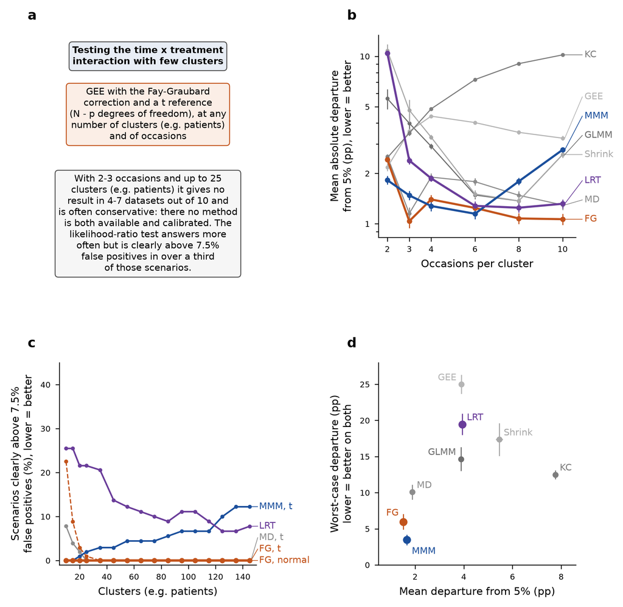

Figura S2. Come la Figura 1, con MMM analizzato come nello studio.

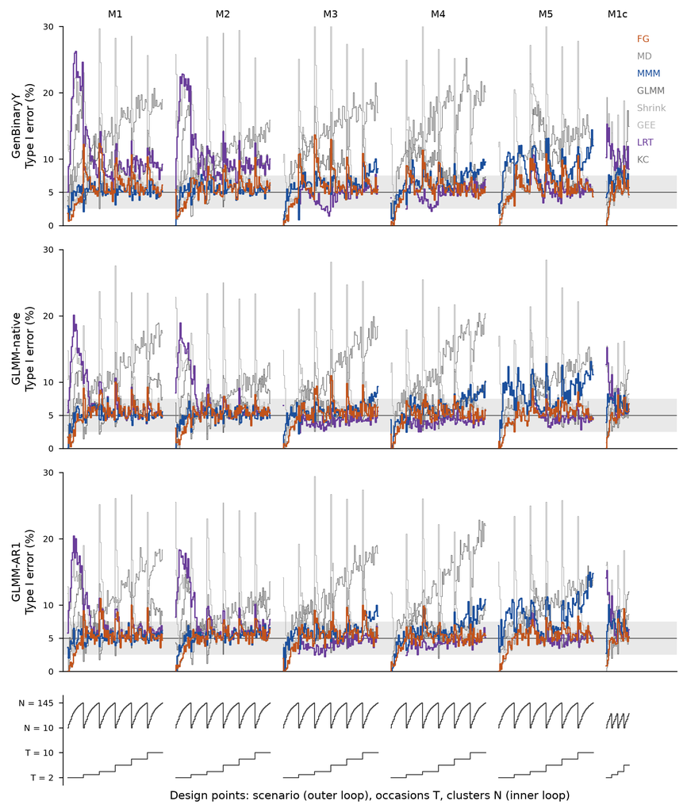

Figura S3. Come la Figura 2, con MMM analizzato come nello studio.